# Flower Classifier

In this project, we trained an image classifier to recognize different species of flowers. We used [this dataset](http://www.robots.ox.ac.uk/~vgg/data/flowers/102/index.html) from Oxford of 102 flower categories. A few examples can be seen below.

[figure not shown]

The project was broken down into multiple steps:

- Load the image dataset and create a pipeline.
- Build and Train an image classifier on this dataset.
- Use the trained model to perform inference on flower images.

## Import Resources

```python
# Make all necessary imports.
import numpy as np
import tensorflow as tf
import tensorflow_datasets as tfds
import tensorflow_hub as hub
from PIL import Image
import matplotlib.pyplot as plt
import matplotlib.image as mpimg
%matplotlib inline

import json
```

## Load the Dataset

We used `tensorflow_datasets` to load the [Oxford Flowers 102 dataset](https://www.tensorflow.org/datasets/catalog/oxford_flowers102). This dataset has 3 splits: `'train'`, `'test'`, and `'validation'`. We also made sure the training data is normalized and resized to 224x224 pixels as required by the pre-trained networks (used later).

```python
# Load the dataset with TensorFlow Datasets.
dataset, dataset_info = tfds.load("oxford_flowers102", as_supervised=True, with_info=True)

# Create a training set, a validation set and a test set.
training_set = dataset["train"]
validation_set = dataset["validation"]
test_set = dataset["test"]
```

## Explore the Dataset

```python
# Get the number of examples in each set from the dataset info.
train_set_size = dataset_info.splits["train"].num_examples
val_set_size   = dataset_info.splits["validation"].num_examples
test_set_size  = dataset_info.splits["test"].num_examples
print("Training set size: {}\nValidation set size: {}\nTest set size: {}".format(train_set_size, val_set_size, test_set_size))

# Get the number of classes in the dataset from the dataset info.
n_classes = dataset_info.features["label"].num_classes
print("Number of classes: {}".format(n_classes))
```

```
Training set size: 1020
Validation set size: 1020
Test set size: 6149
Number of classes: 102
```

```python
# Print the shape and corresponding label of 3 images in the training set.
for image, label in training_set.take(3):
    print("Image shape: {}\nImage label: {}\n".format(image.shape, label))
```

```
Image shape: (500, 667, 3)
Image label: 72

Image shape: (500, 666, 3)
Image label: 84

Image shape: (670, 500, 3)
Image label: 70
```

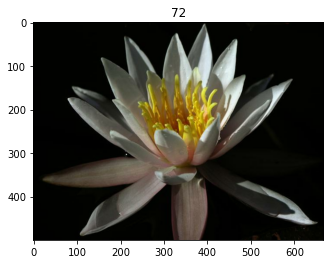

```python
# Plot 1 image from the training set. Set the title
# of the plot to the corresponding image label.
for image, label in training_set.take(1):
    img = image.numpy()
    plt.imshow(img)
    plt.title(label.numpy())
```

### Label Mapping

We loaded in a mapping from label to category name. This can be found in the file `label_map.json`.

```python
with open('label_map.json', 'r') as f:
    class_names = json.load(f)
```

[figure not shown]

```python
# Plot 1 image from the training set.
for image, label in training_set.take(1):
    img = image.numpy()
    plt.imshow(img)
    plt.title(class_names[str(label.numpy())]) # set the title of the plot to the corresponding class name
```

## Create Pipeline

```python
# Create a pipeline for each set.
image_size = 224
image_shape = (image_size, image_size, 3)
batch_size = 32

def format_image(image, label):
    image = tf.cast(image, tf.float32)
    image = tf.image.resize(image, (image_size, image_size))
    image /= 255
    return image, label

training_batches = training_set.shuffle(train_set_size//4).map(format_image).batch(batch_size).prefetch(1)
validation_batches = validation_set.map(format_image).batch(batch_size).prefetch(1)
testing_batches = test_set.map(format_image).batch(batch_size).prefetch(1)
```

# Build and Train the Classifier

We used the MobileNet pre-trained model from TensorFlow Hub to get the image features. We then built and trained a new feed-forward classifier using those features.

What we did in this section:

- Load the MobileNet pre-trained network from TensorFlow Hub.
- Define a new, untrained feed-forward network as a classifier.
- Train the classifier.
- Plot the loss and accuracy values achieved during training for the training and validation set.
- Save the trained model as a Keras model.

```python
# Load the MobileNet pre-trained network from TensorFlow Hub
URL = "https://tfhub.dev/google/tf2-preview/mobilenet_v2/feature_vector/4"
feature_extractor = hub.KerasLayer(URL, input_shape=(image_size, image_size, 3))

# Freeze weights and biases so they're not modified during training
feature_extractor.trainable = False
```

```python
# Build the network using the feature extractor as the first layer
model = tf.keras.Sequential([
    feature_extractor,
    tf.keras.layers.Dense(64, activation="relu"),
    tf.keras.layers.Dropout(0.2),
    tf.keras.layers.Dense(n_classes, activation="softmax")
])

model.summary()
```

```
Model: "sequential_1"
_________________________________________________________________
Layer (type)                 Output Shape              Param #
=================================================================
keras_layer (KerasLayer)     (None, 1280)              2257984
_________________________________________________________________
dense_1 (Dense)              (None, 64)                81984
_________________________________________________________________
dropout (Dropout)            (None, 64)                0
_________________________________________________________________
dense_2 (Dense)              (None, 102)               6630
=================================================================
Total params: 2,346,598
Trainable params: 88,614
Non-trainable params: 2,257,984
_________________________________________________________________
```

```python
# Train the model
model.compile(optimizer="adam",
              loss="sparse_categorical_crossentropy",
              metrics=["accuracy"])

# Include checkpoints and early stopping
model_checkpoint = tf.keras.callbacks.ModelCheckpoint('./best_model.h5', monitor='val_loss', save_best_only=True)
early_stopping   = tf.keras.callbacks.EarlyStopping(monitor="val_loss", patience=5)

epochs = 30
history = model.fit(training_batches,
                    epochs=epochs,
                    validation_data=validation_batches,
                    callbacks=[model_checkpoint, early_stopping])
```

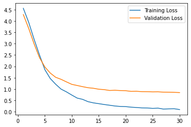

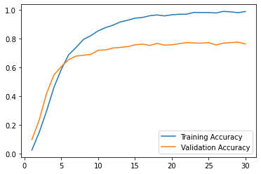

```python
# Plot the loss and accuracy values achieved during training for the training and validation set.
history_dict = history.history

train_loss = history_dict["loss"]
train_accuracy = history_dict["accuracy"]
val_loss = history_dict["val_loss"]
val_accuracy = history_dict["val_accuracy"]
x = range(1, len(train_loss)+1)

plt.figure(1)
plt.plot(x, train_loss)
plt.plot(x, val_loss)
plt.yticks(ticks=np.arange(0.0, max(train_loss), 0.5))
plt.legend(["Training Loss", "Validation Loss"])

plt.figure(2)
plt.plot(x, train_accuracy)
plt.plot(x, val_accuracy)
plt.yticks(ticks=np.arange(0.0, 1.2, 0.2))
plt.legend(["Training Accuracy", "Validation Accuracy"])
plt.show()
```

## Testing the Network

```python
# Print the loss and accuracy values achieved on the entire test set.
loss, accuracy = model.evaluate(testing_batches)
print("Loss: {}\nAccuracy: {}".format(loss, accuracy))
```

```
Loss: 0.9882855415344238
Accuracy: 0.7477638721466064
```

## Save the Model

We saved the model as a Keras model (*i.e.* as an HDF5 file) to be loadable using Keras.

```python
# Save your trained model as a Keras model.
model.save("./best_model.h5")
```

## Load the Keras Model

```python
# Load the Keras model
reloaded_model = tf.keras.models.load_model("./best_model.h5", custom_objects={'KerasLayer':hub.KerasLayer})
```

# Inference for Classification

### Image Pre-processing

The `process_image` function takes in an image (in the form of a NumPy array) and returns an image in the form of a NumPy array with shape `(224, 224, 3)`.

```python
def process_image(image):
    image = tf.convert_to_tensor(image, tf.float32)
    image = tf.image.resize(image, (image_size, image_size))
    image /= 255
    return image.numpy()
```

The code below loads one of the above images using `PIL` and plots the original image alongside the image produced by the `process_image` function.

```python
from PIL import Image

image_path = './test_images/hard-leaved_pocket_orchid.jpg'
im = Image.open(image_path)
test_image = np.asarray(im)

processed_test_image = process_image(test_image)

fig, (ax1, ax2) = plt.subplots(figsize=(10,10), ncols=2)
ax1.imshow(test_image)
ax1.set_title('Original Image')
ax2.imshow(processed_test_image)
ax2.set_title('Processed Image')
plt.tight_layout()
plt.show()
```

[output not shown]